# Statistical Inference Course Project

Neil Bungcayao

9/9/2020

# Part 1: Simulation Exercise

In this project you will investigate the exponential distribution in R and compare it with the Central Limit Theorem. The exponential distribution can be simulated in R with rexp(n, lambda) where lambda is the rate parameter. The mean of exponential distribution is 1/lambda and the standard deviation is also 1/lambda. Set lambda = 0.2 for all of the simulations. You will investigate the distribution of averages of 40 exponentials. Note that you will need to do a thousand simulations.

### Parameters

```r
lambda <- 0.2
n <- 40
simulations <- 1000
```

### Setting the seed number for reproducibility

```r
set.seed(1337)
```

### Simulation

```r
mean = NULL
for (i in 1 : 1000) mean = c(mean, mean(rexp(n, lambda)))
```

### 1. Show the sample mean and compare it to the theoretical mean of the distribution.

#### Sample Mean

```r
samplemean<-mean(mean)
```

##### The sample mean is `samplemean =` **5.0559953**.

#### Theoretical Mean

```r
theoreticalmean <- 1/lambda
```

##### The theoretical mean of the distribution is `theoreticalmean =` **5**.

##### The values of the two means are close to each other.

### 2. Show how variable the sample is (via variance) and compare it to the theoretical variance of the distribution.

#### Sample Variance

```r
samplevariance<-var(mean)
```

##### The sample variance is `samplevariance =` **0.6543703**.

#### Theoretical Variance

```r
theoreticalvariance<- (1/lambda)^2/n
```

##### The theoretical variance of the distribution is `theoreticalvariance =` **0.625**.

##### The values of the two variances are close to each other.

### 3. Show that the distribution is approximately normal.

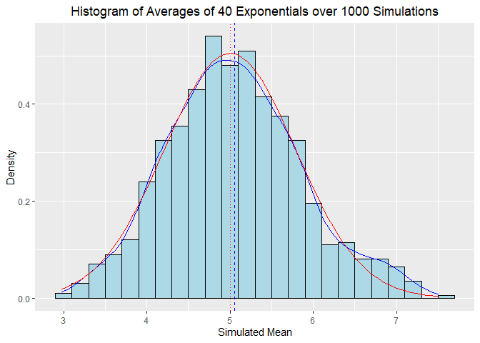

```r
#Transforming the simulated data
data <- data.frame(mean)
#Plotting the Histogram overlayed by the Density of the Simulated Means and the Normal Distribution
#with Parameters from the Exponential Distribution
library(ggplot2)
ggplot(data, aes(x=mean)) +
        geom_histogram(aes(y = ..density..), binwidth = 0.2,  color ="black", fill = "lightblue") +
        geom_density(color = "blue") +
        stat_function(fun=dnorm,args=list(mean=1/lambda, sd=sqrt(theoreticalvariance)),
                      color = "red") +
        geom_vline(xintercept = theoreticalmean, linetype="dotted", color = "red") +
        geom_vline(xintercept = samplemean, linetype="dashed", color = "blue") +
        labs(title = "Histogram of Averages of 40 Exponentials over 1000 Simulations",
             x = "Simulated Mean", y ="Density") +
        theme(plot.title = element_text(hjust = 0.5))
```

# Part 2: Basic Inferential Data Analysis

Now in the second portion of the project, we’re going to analyze the ToothGrowth data in the R datasets package.

## *ToothGrowth* Dataset

### Brief Description

The response is the length of odontoblasts (cells responsible for tooth growth) in 60 guinea pigs. Each animal received one of three dose levels of vitamin C (0.5, 1, and 2 mg/day) by one of two delivery methods, orange juice or ascorbic acid (a form of vitamin C and coded as VC).

### Dataset

| Variable Name | Data Type | Description |
| --- | --- | --- |
| len | numeric | Tooth Length |
| supp | factor | Supplement type (VC or OJ). |
| dose | numeric | Dose in milligrams/day |

### 1. Load the ToothGrowth data and perform some basic exploratory data analyses

#### Loading ToothGrowth Dataset

```r
library(datasets)
library(knitr)
data(ToothGrowth)
kable(ToothGrowth[1:10, ])
```

| len | supp | dose |
| --- | --- | --- |
| 4.2 | VC | 0.5 |
| 11.5 | VC | 0.5 |
| 7.3 | VC | 0.5 |
| 5.8 | VC | 0.5 |
| 6.4 | VC | 0.5 |
| 10.0 | VC | 0.5 |
| 11.2 | VC | 0.5 |
| 11.2 | VC | 0.5 |
| 5.2 | VC | 0.5 |
| 7.0 | VC | 0.5 |

#### Exploratory Data Analysis

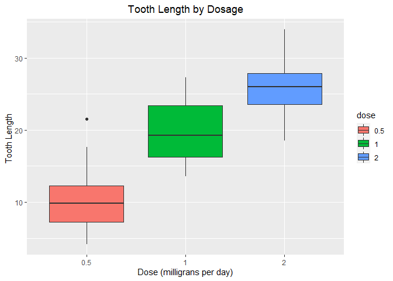

```r
library(ggplot2)
ToothGrowth$dose<-as.factor(ToothGrowth$dose)
ggplot(data = ToothGrowth, aes(x = dose, y = len)) +
  geom_boxplot(aes(fill=dose)) +
  labs(title="Tooth Length by Dosage",
       x = "Dose (milligrans per day)",
       y = "Tooth Length ") +
  theme(plot.title = element_text(hjust = 0.5))
```

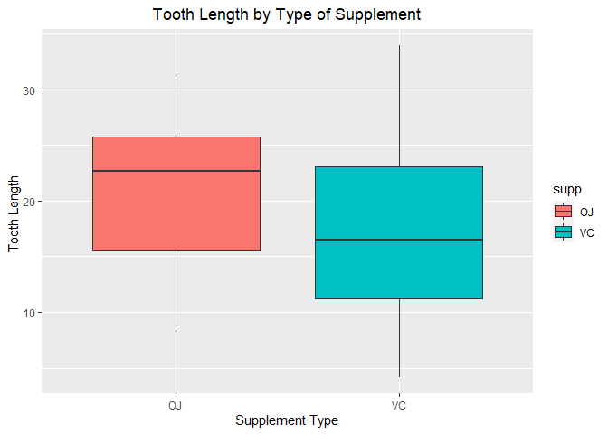

```r
library(ggplot2)
ggplot(data = ToothGrowth, aes(x = supp, y = len)) +
  geom_boxplot(aes(fill=supp)) +
  labs(title="Tooth Length by Type of Supplement",
       x = "Supplement Type",
       y = "Tooth Length ") +
  theme(plot.title = element_text(hjust = 0.5))
```

### 2. Provide a basic summary of the data.

```r
str(ToothGrowth)
```

‘data.frame’: 60 obs. of 3 variables: $ len : num 4.2 11.5 7.3 5.8 6.4 10 11.2 11.2 5.2 7 … $ supp: Factor w/ 2 levels “OJ”,“VC”: 2 2 2 2 2 2 2 2 2 2 … $ dose: Factor w/ 3 levels “0.5”,“1”,“2”: 1 1 1 1 1 1 1 1 1 1 …

```r
summary(ToothGrowth$len)
```

Min. 1st Qu. Median Mean 3rd Qu. Max. 4.20 13.07 19.25 18.81 25.27 33.90

```r
summary(ToothGrowth$supp)
```

OJ VC 30 30

```r
summary(ToothGrowth$dose)
```

0.5 1 2 20 20 20

### 3. Use confidence intervals and/or hypothesis tests to compare tooth growth by supp and dose. (Only use the techniques from class, even if there’s other approaches worth considering)

#### Type of Supplement: OJ vs. VC

```r
t.test(len ~ supp, data = ToothGrowth, var.equal = FALSE)
```

[output not shown]

```
Welch Two Sample t-test
```

```r
library(dplyr)
ToothGrowth_Pair1 <- ToothGrowth %>% filter(dose %in% c(0.5, 1.0))
t.test(len ~  dose, data = ToothGrowth_Pair1, var.equal = FALSE)
```

```
Welch Two Sample t-test
```

data: len by dose t = -6.4766, df = 37.986, p-value = 1.268e-07 alternative hypothesis: true difference in means is not equal to 0 95 percent confidence interval: -11.983781 -6.276219 sample estimates: mean in group 0.5 mean in group 1 10.605 19.735

#### Dosage: 0.5 vs 2.0

```r
library(dplyr)
ToothGrowth_Pair2 <- ToothGrowth %>% filter(dose %in% c(0.5, 2.0))
t.test(len ~  dose, data = ToothGrowth_Pair2, var.equal = FALSE)
```

```
Welch Two Sample t-test
```

data: len by dose t = -11.799, df = 36.883, p-value = 4.398e-14 alternative hypothesis: true difference in means is not equal to 0 95 percent confidence interval: -18.15617 -12.83383 sample estimates: mean in group 0.5 mean in group 2 10.605 26.100

#### Dosage: 1.0 vs 2.0

```r
library(dplyr)
ToothGrowth_Pair3 <- ToothGrowth %>% filter(dose %in% c(1.0, 2.0))
t.test(len ~  dose, data = ToothGrowth_Pair3, var.equal = FALSE)
```

```
Welch Two Sample t-test
```

data: len by dose t = -4.9005, df = 37.101, p-value = 1.906e-05 alternative hypothesis: true difference in means is not equal to 0 95 percent confidence interval: -8.996481 -3.733519 sample estimates: mean in group 1 mean in group 2 19.735 26.100

### 4. State your conclusions and the assumptions needed for your conclusions.

#### Assumptions

1. Unequal Variances
2. The distribution of the mean tooth growth is approsimately normal.
3. Randomization mechanism is applied on which guinea pigs will receive a certain type of treatment.
4. Independent and Identcally Distributed for all elements on the study.